# Markdown Files — My sample book

## Data Cleaning

untuk data yang saya gunakan sudah tidak memiliki data duplikat atau data yang muncul lebih dari satu kali, namun pada kali ini saya berusaha untuk mencoba menghilangkan duplikasi datanya kembali.

```python
df = df.drop_duplicates()
```

## Exploratory Data Analysis (EDA)

```python
df.describe()
```

[output not shown]

[figure not shown]

```python
palette = sns.color_palette("Set2", n_colors=len(df['Provinsi'].unique()))  # Mengatur jumlah warna sesuai dengan jumlah Provinsi
    plt.figure(figsize=(14, 5))
    sns.barplot(data=df, x='Provinsi', y='Produksi', palette=palette)
    plt.title('Perbandingan produksi padi antar Provinsi di Pulau Sumatera')
    plt.show()
```

Dari hasil visualisasi data diatas dapat dilihat bahwa Provinsi terbanyak memproduksi padi berasal dari sumatera utara

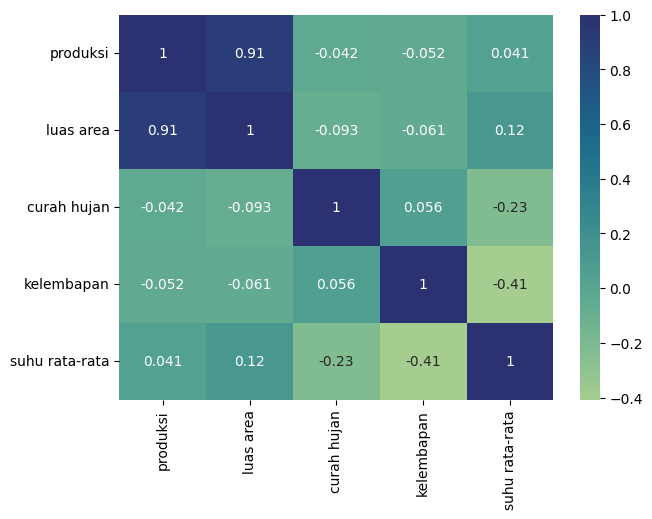

```python
plt.figure(figsize=(7, 5))
    sns.heatmap(df.drop(['Provinsi', 'tahun'], axis=1).corr(), annot=True, cmap='crest')
    plt.show()
```

Dari hasil pengamatan visualisasi matriks diatas dapat dismpulkan bahwa luas area tanam adlah faktor utama yang dapat mempengaruhi produksi padi di wilayah yang di teliti.

Dan untuk curah hujan, kelembapan, dan suhu rata-rata tidak menunjukkan pengaruh yang kuat terhadap produksi, meskipun terdapat beberapa hubungan yang signifikan antara suhu rata-rata dan kelembapan.

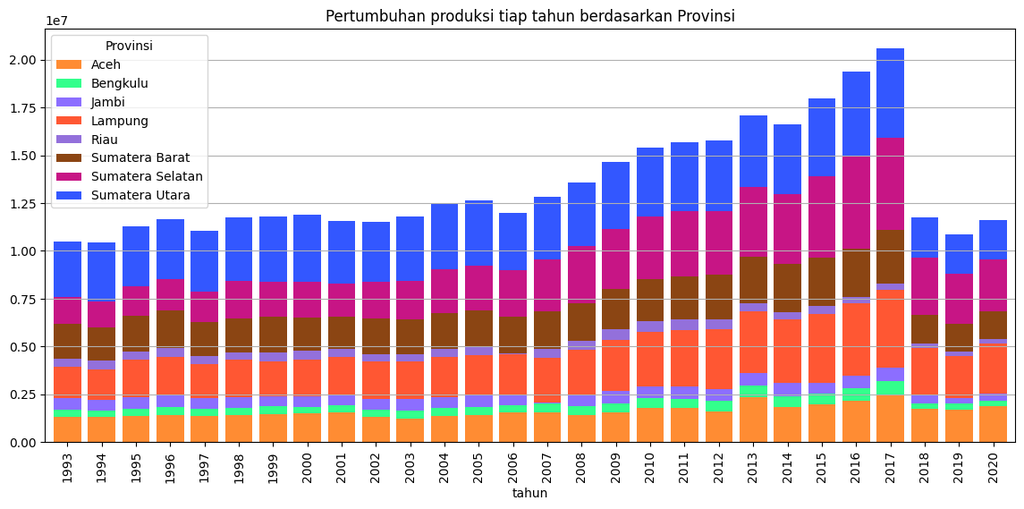

```python
colors = ['#ff8c33', '#33ff8c', '#8c6eff', '#ff5733', '#9370db', '#8b4513', '#c71585', '#3357ff']
    df.pivot_table(index='tahun', columns='Provinsi', values='produksi').plot.bar(width=0.8, stacked=True, figsize=(14, 6), color=colors)
    plt.title("Pertumbuhan produksi tiap tahun berdasarkan Provinsi")
    plt.grid(axis='y', which='major')
    # plt.legend(loc='best')
    plt.show()
```

Dapat dilihat dari visualisasi diatas yakni hasil produksi padi diatas sumatera utara mengalami kenaikan dari tahun 2003-2017 namun mengalami penurunan yang signifikan pada tahun 2018-2020

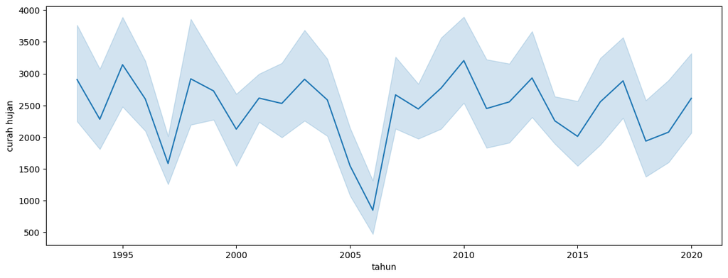

```python
plt.figure(figsize=(14, 5))
    sns.lineplot(df, x='tahun', y='curah hujan')
    plt.show()
```

Pada tahun 2005 mengalami penurunan curah hujan secara drastis daripada sebelumnya dan mengalami kenaikan kembali yang kemudian menjadi rata hingga tahun 2020

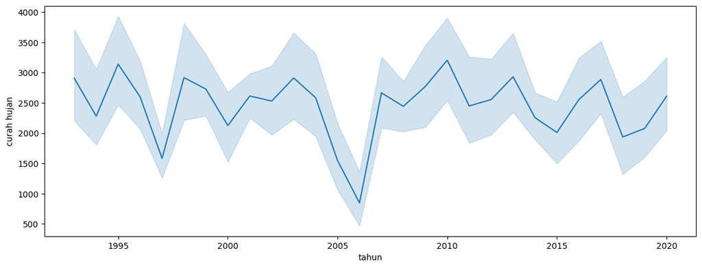

```python
plt.figure(figsize=(14, 5))
    sns.lineplot(df, x='tahun', y='curah hujan')
    plt.show()
```

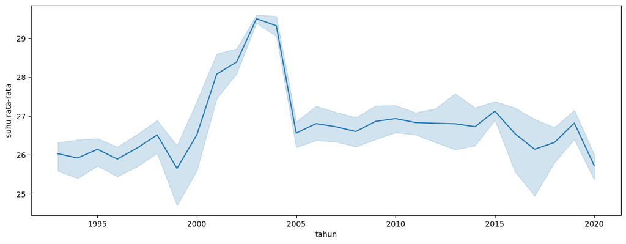

```python
plt.figure(figsize=(14, 5))
    sns.lineplot(df, x='tahun', y='suhu rata-rata')
    plt.show()
```

Terjadi kenaikan suhu rata-rata pada tahun 2000 sampai 2005 dan kembali stagnan pada tahun 2005 sampai 2015 dengan sedikit perubahan kenaikan suhu rata-rata.

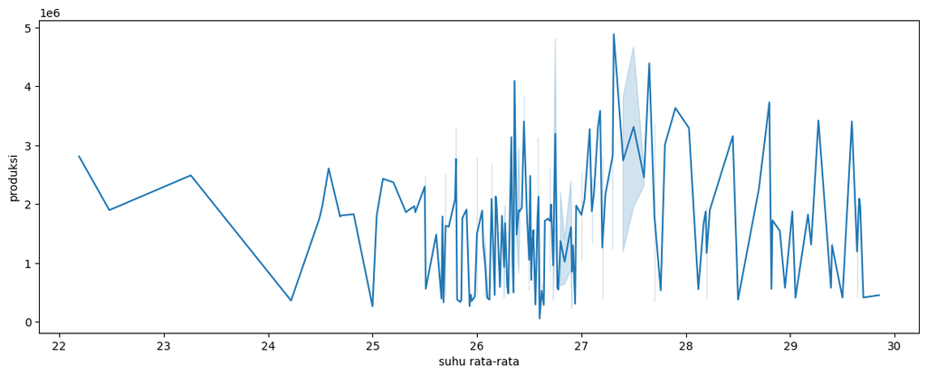

```python
plt.figure(figsize=(14, 5))
    sns.lineplot(df, x='suhu rata-rata', y='produksi')
    plt.show()
```

Dalam suhu rata-rata 26-27 terjadi perubahan produksi yang berubah-ubah dibandingkan dengan suhu rata-rata 22-23.

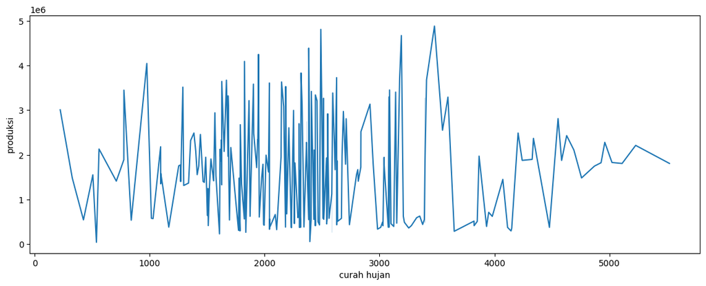

```python
plt.figure(figsize=(14, 5))
    sns.lineplot(df, x='curah hujan', y='produksi')
    plt.show()
```

Produksi sangat meningkat ketika curah hujan mencapai lebih dari 2000 dan tidak lebih dari 3500. Namun tidak semuanya mengalami peningkatan. Hanya beberapa titik curah hujan saja yang terjadinya peningkatan dan penurunan secara signifikan.

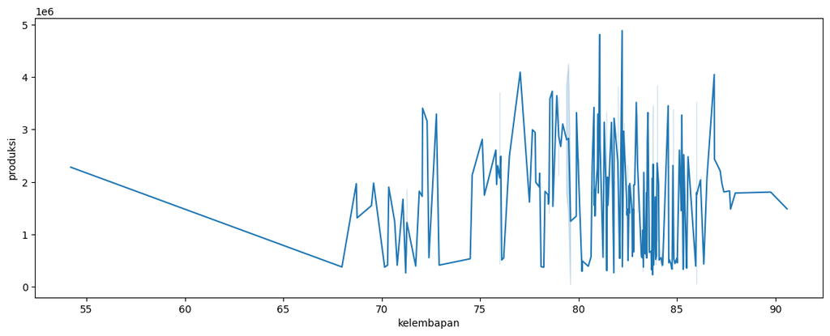

```python
plt.figure(figsize=(14, 5))
    sns.lineplot(df, x='kelembapan', y='produksi')
    plt.show()
```

Kelembaban tanah juga menjadi faktor penting pertumbuhan padi. Apabila kelembaban rendah saat fase reproduktif dapat menyebabkan pembungaan terhambat. Pada grafik di atas terlihat bahwa di kelembapan 80an memiliki titik produksi tertinggi namun tidak stabil.

## Data Preprocessing

```python
# Mengecek apakah ada missing value dalam dataset
    print(df.isnull().sum())

    # Metode 1: Mengisi missing value dengan mean dari setiap kolom (imputasi mean)
    # Select only numeric columns for calculating the mean
    numeric_cols = df.select_dtypes(include=np.number).columns
    df[numeric_cols] = df[numeric_cols].fillna(df[numeric_cols].mean())

    # Metode 2: Mengisi missing value dengan median dari setiap kolom (imputasi median)
    # df.fillna(df.median(), inplace=True)

    # Metode 3: Menghapus baris yang mengandung missing value
    # df.dropna(inplace=True)

    print(df.isnull().sum())
    # Select only numeric columns for calculating the mean
    numeric_cols = df.select_dtypes(include=np.number).columns
    df[numeric_cols] = df[numeric_cols].fillna(df[numeric_cols].mean())
```

```
Provinsi          0
    tahun             0
    produksi          0
    luas area         0
    curah hujan       0
    kelembapan        0
    suhu rata-rata    0
    dtype: int64
    Provinsi          0
    tahun             0
    produksi          0
    luas area         0
    curah hujan       0
    kelembapan        0
    suhu rata-rata    0
    dtype: int64
```

Menghapus data yang tidak memiliki keterkaitan dengan target yakni produksi

```python
X = df.drop(['produksi','tahun', 'Provinsi'], axis=1)
    y = df[['produksi']]
```

```python
X_train, X_test, y_train, y_test = train_test_split(X, y, test_size=0.2, random_state=42)
    print(f'X_train: {X_train.shape}')
    print(f'X_test: {X_test.shape}\n')
    print(f'y_train: {y_train.shape}')
    print(f'y_test: {y_test.shape}')
```

```
X_train: (179, 4)
    X_test: (45, 4)

    y_train: (179, 1)
    y_test: (45, 1)
```

```python
sc = StandardScaler()
    X_train = sc.fit_transform(X_train)
    X_test = sc.transform(X_test)

    y_train = sc.fit_transform(y_train)
    y_test = sc.transform(y_test)
```

## Modelling

### Regresi Linear

```python
LinReg = LinearRegression()
    LinReg.fit(X_train, y_train)

    y_pred_Lr = LinReg.predict(X_test)
    y_pred_Lr = pd.DataFrame(y_pred_Lr)
    y_pred_Lr.sample(5)
```

|  | 0 |
| --- | --- |
| 10 | 0.055727 |
| 7 | -0.939311 |
| 41 | 0.236981 |
| 33 | -0.969028 |
| 28 | 0.148295 |

### Pohon Keputusan

```python
DTreeReg = DecisionTreeRegressor(random_state = 0)
    DTreeReg.fit(X_train, y_train)

    ypred_DTreeReg = DTreeReg.predict(X_test)
    y_pred_DTreeReg = pd.DataFrame(ypred_DTreeReg)
    y_pred_DTreeReg.head()
```

|  | 0 |
| --- | --- |
| 0 | -0.400946 |
| 1 | -1.388808 |
| 2 | -0.977200 |
| 3 | 0.189738 |
| 4 | 0.509172 |

### Support Vector Regression (SVR)

```python
svr_model = SVR(kernel='rbf')
    svr_model.fit(X_train, y_train)
    y_pred_SVR = svr_model.predict(X_test)
```

### Random Forest

```python
RF_model = RandomForestRegressor(random_state=0)
    RF_model.fit(X_train, y_train)
    ypred_RF = RF_model.predict(X_test)
```

## Model Evaluation

### Regresi Linear

```python
# Evaluasi model
    mse = mean_squared_error(y_test, y_pred_Lr)
    mae = mean_absolute_error(y_test, y_pred_Lr)
    r2 = r2_score(y_test, y_pred_Lr)
    rmse = np.sqrt(mse)

    # Menampilkan hasil evaluasi
    print("Root Mean Squared Error:", rmse)
    print("Mean Squared Error:", mse)
    print("Mean Absolute Error:", mae)
    print("R-squared:", r2)
```

```
Root Mean Squared Error: 0.2820960836856911
    Mean Squared Error: 0.07957820043080445
    Mean Absolute Error: 0.2017257598897857
    R-squared: 0.8698382149351499
```

```python
data  = {
        'actual': y_test.reshape(1,-1)[0],
        'predicted': np.array(y_pred_Lr).reshape(1,-1)[0]
    }

    eval = pd.DataFrame(data)
    eval.head()
```

|  | actual | predicted |
| --- | --- | --- |
| 0 | -0.344773 | -0.347937 |
| 1 | -1.074780 | -0.863702 |
| 2 | -0.979998 | -0.774902 |
| 3 | -0.125877 | 0.332913 |
| 4 | 0.631884 | 0.557542 |

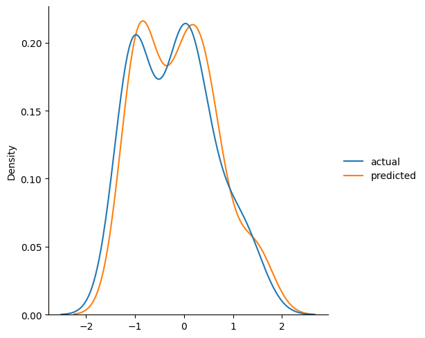

```python
sns.displot(data=eval, kind="kde")
    plt.show()
```

### Pohon Keputusan

```python
# Evaluasi model
    mse = mean_squared_error(y_test, y_pred_DTreeReg)
    mae = mean_absolute_error(y_test, y_pred_DTreeReg)
    r2 = r2_score(y_test, y_pred_DTreeReg)
    rmse = np.sqrt(mse)

    # Menampilkan hasil evaluasi
    print("Root Mean Squared Error:", rmse)
    print("Mean Squared Error:", mse)
    print("Mean Absolute Error:", mae)
    print("R-squared:", r2)
```

```
Root Mean Squared Error: 0.3896982884325476
    Mean Squared Error: 0.15186475600725707
    Mean Absolute Error: 0.20807026157527284
    R-squared: 0.7516029814279293
```

```python
data  = {
        'actual': y_test.reshape(1,-1)[0],
        'predicted': np.array(y_pred_DTreeReg).reshape(1,-1)[0]
    }

    eval = pd.DataFrame(data)
    eval.head()
```

|  | actual | predicted |
| --- | --- | --- |
| 0 | -0.344773 | -0.400946 |
| 1 | -1.074780 | -1.388808 |
| 2 | -0.979998 | -0.977200 |
| 3 | -0.125877 | 0.189738 |
| 4 | 0.631884 | 0.509172 |

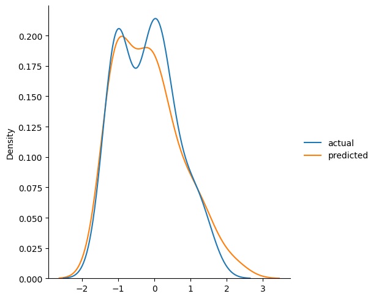

```python
sns.displot(data=eval, kind="kde")
    plt.show()
```

### SVR

```python
mse_svr = mean_squared_error(y_test, y_pred_SVR)
    mae_svr = mean_absolute_error(y_test, y_pred_SVR)
    r2_svr = r2_score(y_test, y_pred_SVR)
    rmse_svr = np.sqrt(mse_svr)


    # Menampilkan hasil evaluasi
    print("\nSupport Vector Regression:")
    print("Root Mean Squared Error:", rmse_svr)
    print("Mean Squared Error:", mse_svr)
    print("Mean Absolute Error:", mae_svr)
    print("R-squared:", r2_svr)
```

```
    Support Vector Regression:
    Root Mean Squared Error: 0.23245624229764555
    Mean Squared Error: 0.054035904583141704
    Mean Absolute Error: 0.17090252973351489
    R-squared: 0.911616375338226
```

```python
data  = {
        'actual': y_test.reshape(1,-1)[0],
        'predicted': np.array(y_pred_SVR).reshape(1,-1)[0]
    }

    eval = pd.DataFrame(data)
    eval.head()
```

|  | actual | predicted |
| --- | --- | --- |
| 0 | -0.344773 | -0.272451 |
| 1 | -1.074780 | -1.029133 |
| 2 | -0.979998 | -0.864276 |
| 3 | -0.125877 | 0.349546 |
| 4 | 0.631884 | 0.558323 |

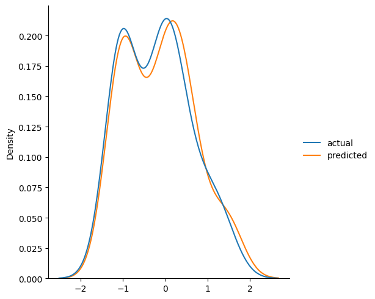

```python
sns.displot(data=eval, kind="kde")
    plt.show()
```

### Radom Forest

```python
# Menghitung metrik evaluasi
    mse_rf = mean_squared_error(y_test, ypred_RF)
    mae_rf = mean_absolute_error(y_test, ypred_RF)
    r2_rf = r2_score(y_test, ypred_RF)
    rmse_rf = np.sqrt(mse_rf)

    # Menampilkan hasil evaluasi
    print("\nRandom Forest Regression:")
    print("Root Mean Squared Error:", rmse_rf)
    print("Mean Squared Error:", mse_rf)
    print("Mean Absolute Error:", mae_rf)
    print("R-squared:", r2_rf)
```

```
    Random Forest Regression:
    Root Mean Squared Error: 0.2482233028745926
    Mean Squared Error: 0.061614808089971725
    Mean Absolute Error: 0.1714518478213724
    R-squared: 0.8992199702430765
```

```python
data  = {
        'actual': y_test.reshape(1,-1)[0],
        'predicted': np.array(ypred_RF).reshape(1,-1)[0]
    }

    eval = pd.DataFrame(data)
    eval.head()
```

|  | actual | predicted |
| --- | --- | --- |
| 0 | -0.344773 | -0.270100 |
| 1 | -1.074780 | -1.232639 |
| 2 | -0.979998 | -0.932742 |
| 3 | -0.125877 | 0.201806 |
| 4 | 0.631884 | 0.354118 |

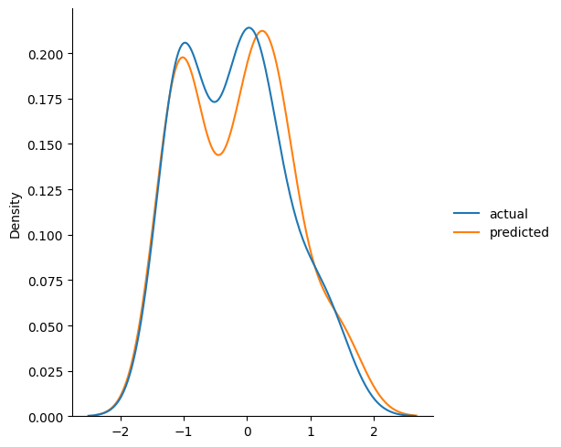

```python
sns.displot(data=eval, kind="kde")
    plt.show()
```

Kesimpulannya adalah pemodelan untuk prediksi produksi padi di pulau sumatera yang baik adalah dengan menggunakan svr